# Data Science in Gaming

Caleb Bales

2/13/2023

Date that the [article](https://medium.com/@-TutortAcademy/data-science-in-gaming-357c38c690cc) was published: **January 7, 2022**

Written by: **Tutort Academy**

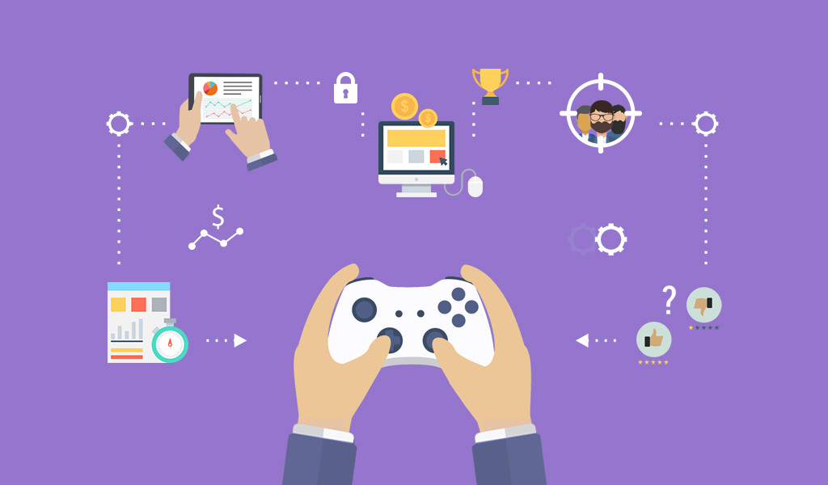

A relative infographic showing I know how to control height/width

### Summary of Article

The main focus of this article is the role of Data Science in the industry of one of my favorite hobbies, video games. Specifically, the article explains how the major players of the industry, such as EA, Sony, Microsoft, etc. have began to use data to improve the user’s experience and engagement with their content. Mainly these companies, along with many indie developers, utilize Artificial Intelligence, Machine Learning, and Data Mining techniques to improve both players and developer enjoyment of games.

### One “Real World” Application

One, “real-life use case,” which the article describes is how machine learning and AI solve a problematic phenomenon in gaming known as, “Power Boosting.” This is a tactic used frequently in online, multi-player games such as those in the Call of Duty series. Essentially, one friend will purposely loose an online match because there is another friend on the opposing team. This leads to the winning player increasing in rank/level even though they really didn’t do anything. This hurts the skill based matchmaking of most games, so ML models are implemented to detect which such “virtual crimes” occur. Mainly the variables these models look at are if the players are friends with each other, but not on the same team repeatedly, and if player deaths occur at the same location in rapid succession.

### Ethics of Data Science in Gaming

One aspect which this article doesn’t go into which I feel needs to be addressed, is the ethics behind Data Science in gaming. While many aspects of Data Science can improve this entertainment industry, such as the previously mentioned instance with preventing power boosting, there are also many ways which I see big data hurting gaming in general. One such way is the explosion of cheap, predatory mobile games which have came about in recent years.

[figure not shown]

A classic example of cheap mobile game ads

These games are usually advertised on social media platforms like Instagram, Tiktok, and many others. The reason these games are “predatory” are because they are teetering on the line of false advertisement and prey on addictive personalities. These games, such as in the lefthand section of the photo above, don’t actually play as advertised. Usually, the advertised game is a mini-game inside a worse quality, ad-packed game, and this is why false advertising has yet to catch up to these products, just by a loophole. In fact, the companies behind these games use the data of players with addictive personalities to build the games for these adds in the first place. I do believe data science does industries good 9 times out of 10, but I think it’s also important to look out for that 1/10 occurence.

### Relevance to My (Hopeful) Career

This article has, at the very least, informed me on how the field of Data Science has been applied to one of my favorite hobbies. Unfortunately, even though I really like both Data Science and gaming, I don’t think I’ll be pursuing a career in game development as a Data Scientist. For one, the games industry is just under teachers in terms of unfair working conditions and lack of labor laws. Furthermore, I think that getting too close to my favorite hobby with my (hopeful) future profession as a Software Developer/Data Analyst could perhaps take some of the wide-eyed wonder away.

### Required Plots

#### mtcars plot

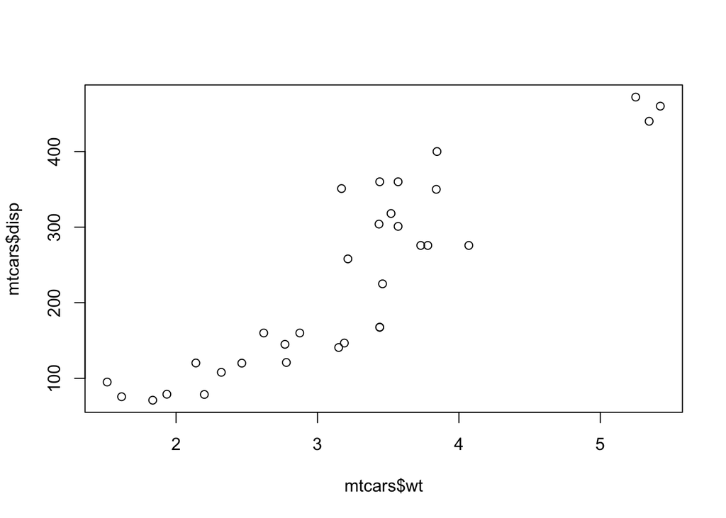

```r
plot(mtcars$wt, mtcars$disp)
```

#### US Arrests DT

|  | Murder | Assault | UrbanPop | Rape |
| --- | --- | --- | --- | --- |
| Alabama | 13.2 | 236 | 58 | 21.2 |
| Alaska | 10 | 263 | 48 | 44.5 |
| Arizona | 8.1 | 294 | 80 | 31 |
| Arkansas | 8.8 | 190 | 50 | 19.5 |
| California | 9 | 276 | 91 | 40.6 |
| Colorado | 7.9 | 204 | 78 | 38.7 |
| Connecticut | 3.3 | 110 | 77 | 11.1 |
| Delaware | 5.9 | 238 | 72 | 15.8 |
| Florida | 15.4 | 335 | 80 | 31.9 |
| Georgia | 17.4 | 211 | 60 | 25.8 |

[output cut: 40 more lines]